# GLM: Introduction

2018-05-15

## The Generalized Linear Model: GLM

- 3.0 Introduction
- 3.1 Intervals & Tests
- 3.2 Residuals & Assumptions
- 3.3 Let's practice more

## You will learn in this session

- how to write a GLM
- that GLM can be fitted on different type of responses
- what a link function, a variance function and a linear predictor are
- how to simulate the data for a GLM
- how to use the R family objects
- how to convert values between the response and linear predictor scales
- that GLM estimates are fitted by maximum likelihood
- that GLM can be fitted analytically only using an iterative approach
- how to interpret parameter estimates from GLM Poisson and Binomial

## Definition and notations

## Mathematical notations of GLM

\(\eta_i = \beta_0 + \beta_1 \times x_{1,i} + \beta_2 \times x_{2,i} + \dots + \beta_{p} \times x_{p,i}\) or in matrix notation \(\eta = \text{X}\beta\) ,

with:

- \(\text{E}(\text{Y}) = \mu = g^{-1}(\eta)\)
- \(\text{Var}(\text{Y}) = \phi\text{V}(\mu)\)

We call:

- \(\eta\) the linear predictor
- \(g\) the link function (\(g^{-1}\) is sometimes called the mean function)
- \(\text{V}\) the variance function
- \(\phi\) is the dispersion parameter

The GLM fit leads to \(\text{Y} = g^{-1}(\eta) + \epsilon = g^{-1}(\text{X}\beta) + \epsilon = g^{-1}(\widehat{\eta})+ \varepsilon = g^{-1}(\text{X}\widehat{\beta}) + \varepsilon\)

Here the errors can have a distribution other than Gaussian.

## LM is a particular case of GLM!

\(\eta_i = \beta_0 + \beta_1 \times x_{1,i} + \beta_2 \times x_{2,i} + \dots + \beta_{p} \times x_{p,i}\) or in matrix notation \(\eta = \text{X}\beta\) ,

with:

- \(\text{E}(\text{Y}) = \mu = g^{-1}(\eta)\)
- \(\text{Var}(\text{Y}) = \phi\text{V}(\mu)\)

This is identical to the LM if:

- \(\mu = g^{-1}(\eta) = \eta\), thus if \(g\) is the identity function
- \(\phi = \sigma^2\), thus if the dispersion parameter equals the error variance
- \(\text{V}(\mu) = 1\), thus if the variance function is constant

So in GLM, the probability distribution of \(\text{Y}\) can be Gaussian.

## GLM can do more than LM!

### The response

- one dimension: \(n \times 1\)
- continuous or categorical
- member of the univariate linear exponential family: \(f(y; \theta; \phi) = \text{exp}\left( \frac{y\theta-b(\theta)}{a(\phi)} + c(y; \phi)\right)\)

This includes:

- the normal distribution (for many continuous outcomes)
- the binomial distribution (for binary or binomial outcomes)
- the Poisson distribution (for counts)
- the gamma distribution (for continuous positive outcomes such as survival times)
- the inverse Gaussian (for continuous positive outcomes as well; the name is misleading)
- other less main steam distributions

## What do we need to fit a GLM?

- data = response variable + design matrix, as for LM
- the probability distribution (e.g. Gaussian, Poisson…) which sets the variance function
- the link function

The probability distribution and the link function are obtained in R by calling the `family` functions:

```r
gaussian(link = "identity")
binomial(link = "logit")
poisson(link = "log")
Gamma(link = "inverse")
inverse.gaussian(link = "1/mu^2")
```

The objects of class `family` created by these functions also contain other useful information needed for the fitting procedure (we will see that later).

## Examples

## Simulating data for GLM

```r
set.seed(1L)
Aliens <- data.frame(humans_eaten = round(runif(n = 100, min = 0, max = 15)))
Aliens$size  <- rnorm( n = 100, mean = 50 + 1.5 * Aliens$humans_eaten, sd = 5)
Aliens$eggs  <- rpois( n = 100, lambda = exp(-1 + 0.1 * Aliens$humans_eaten))
Aliens$happy <- rbinom(n = 100, size = 1, prob = plogis(-3 + 0.3 * Aliens$humans_eaten))
Aliens$all_eyes  <- round(runif(nrow(Aliens), min = 1, max = 12))
Aliens$blue_eyes <- rbinom(n = nrow(Aliens), size = Aliens$all_eyes,
                           prob = plogis(-2 + 0.5 * Aliens$humans_eaten))
Aliens$pink_eyes <- Aliens$all_eyes - Aliens$blue_eyes
head(Aliens)
```

```
##   humans_eaten     size eggs happy all_eyes blue_eyes pink_eyes
## 1            4 57.99053    1     0        7         5         2
## 2            6 55.93987    0     0        9         5         4
## 3            9 65.20560    1     1        8         8         0
## 4           14 65.35318    1     0        8         8         0
## 5            3 61.66512    0     1        6         5         1
## 6           13 79.40200    5     0       12        11         1
```

## Fitting the GLM

```r
mod_gauss <- glm(size  ~ humans_eaten, family = gaussian(), data = Aliens)
mod_poiss <- glm(eggs  ~ humans_eaten, family = poisson(),  data = Aliens)
mod_binar <- glm(happy ~ humans_eaten, family = binomial(), data = Aliens)
mod_binom <- glm(cbind(blue_eyes, pink_eyes) ~ humans_eaten, family = binomial(), data = Aliens)

## Example of output:
mod_binom
```

```
##
## Call:  glm(formula = cbind(blue_eyes, pink_eyes) ~ humans_eaten, family = binomial(),
##     data = Aliens)
##
## Coefficients:
##  (Intercept)  humans_eaten
##      -2.2481        0.5129
##
## Degrees of Freedom: 99 Total (i.e. Null);  98 Residual
## Null Deviance:       398.8
## Residual Deviance: 92.83     AIC: 199.4
```

## The GLM object

## Components stored in GLM objects

```r
names(mod_gauss)
```

```
##  [1] "coefficients"      "residuals"         "fitted.values"     "effects"           "R"
##  [6] "rank"              "qr"                "family"            "linear.predictors" "deviance"
## [11] "aic"               "null.deviance"     "iter"              "weights"           "prior.weights"
## [16] "df.residual"       "df.null"           "y"                 "converged"         "boundary"
## [21] "model"             "call"              "formula"           "terms"             "data"
## [26] "offset"            "control"           "method"            "contrasts"         "xlevels"
```

```r
names(mod_binom)
```

```
##  [1] "coefficients"      "residuals"         "fitted.values"     "effects"           "R"
##  [6] "rank"              "qr"                "family"            "linear.predictors" "deviance"
## [11] "aic"               "null.deviance"     "iter"              "weights"           "prior.weights"
## [16] "df.residual"       "df.null"           "y"                 "converged"         "boundary"
## [21] "model"             "call"              "formula"           "terms"             "data"
## [26] "offset"            "control"           "method"            "contrasts"         "xlevels"
```

The components are the same no matter the family.

We will only detail the interesting ones.

## Coefficients (`coefficients`)

```r
mod_gauss$coefficients
```

```
##  (Intercept) humans_eaten
##    49.180669     1.593894
```

```r
mod_poiss$coefficients
```

```
##  (Intercept) humans_eaten
##  -0.42147860   0.03635067
```

```r
mod_binom$coefficients
```

```
##  (Intercept) humans_eaten
##   -2.2480549    0.5129418
```

Same idea as for LM, but here they are expressed in the scale of the linear predictor!!!

## The residuals (`residuals`)

As we shall see later, those are the working residuals:

```r
rbind(mod_poiss$residuals[1:2], residuals(mod_poiss, type = "working")[1:2])
```

```
##              1  2
## [1,] 0.3179479 -1
## [2,] 0.3179479 -1
```

```r
rbind(mod_binom$residuals[1:2], residuals(mod_binom, type = "working")[1:2])
```

```
##             1          2
## [1,] 1.062976 -0.6653824
## [2,] 1.062976 -0.6653824
```

Although useful during the fitting procedure, these residuals are not useful to us.

We will see that we can extract other types of residuals that are more useful with `residuals()`.

## Linear predictors (`linear.predictors`)

This contains the predicted values for the observations at the scale of the linear predictor.

```r
rbind(summary(mod_gauss$linear.predictors),
      summary(mod_poiss$linear.predictors),
      summary(mod_binar$linear.predictors),
      summary(mod_binom$linear.predictors)
      )
```

```
##            Min.    1st Qu.     Median       Mean     3rd Qu.       Max.
## [1,] 49.1806693 57.1501386 60.3379264 61.5971025 67.11197531 73.0890773
## [2,] -0.4214786 -0.2397252 -0.1670239 -0.1383069 -0.01253353  0.1237815
## [3,] -1.6012666 -0.6913834 -0.3274301 -0.1836685  0.44597066  1.1283831
## [4,] -2.2480549  0.3166541  1.3425377  1.7477617  3.52254034  5.4460721
```

## Linear predictors (`linear.predictors`)

They are computed as in LM:

```r
rbind(mod_gauss$linear.predictors[1:2], (model.matrix(mod_gauss) %*% mod_gauss$coefficients)[1:2])
```

```
##             1        2
## [1,] 55.55624 58.74403
## [2,] 55.55624 58.74403
```

```r
rbind(mod_poiss$linear.predictors[1:2], (model.matrix(mod_poiss) %*% mod_poiss$coefficients)[1:2])
```

```
##               1          2
## [1,] -0.2760759 -0.2033746
## [2,] -0.2760759 -0.2033746
```

```r
rbind(mod_binom$linear.predictors[1:2], (model.matrix(mod_binom) %*% mod_binom$coefficients)[1:2])
```

```
##               1         2
## [1,] -0.1962877 0.8295959
## [2,] -0.1962877 0.8295959
```

## Fitted values (`fitted.values`)

This contains the predicted values for the observations at the scale of the response:

```r
rbind(summary(mod_gauss$fitted.values),
      summary(mod_poiss$fitted.values))
```

```
##           Min.   1st Qu.     Median    Mean    3rd Qu.      Max.
## [1,] 49.180669 57.150139 60.3379264 61.5971 67.1119753 73.089077
## [2,]  0.656076  0.786844  0.8461794  0.8800  0.9876678  1.131769
```

For binomial family, the fitted values is a probability:

```r
rbind(summary(mod_binar$fitted.values),
      summary(mod_binom$fitted.values))
```

```
##            Min.   1st Qu.    Median     Mean   3rd Qu.      Max.
## [1,] 0.16780467 0.3337254 0.4188661 0.460000 0.6095095 0.7555404
## [2,] 0.09551738 0.5785086 0.7929070 0.729163 0.9707196 0.9957053
```

## Fitted values (`fitted.values`)

The fitted values are obtained from the linear predictors:

```r
rbind(mod_gauss$fitted.values[1:2], gaussian()$linkinv(mod_gauss$linear.predictors[1:2]))
```

```
##             1        2
## [1,] 55.55624 58.74403
## [2,] 55.55624 58.74403
```

```r
rbind(mod_poiss$fitted.values[1:2], poisson()$linkinv(mod_poiss$linear.predictors[1:2]))
```

```
##              1         2
## [1,] 0.7587553 0.8159726
## [2,] 0.7587553 0.8159726
```

```r
rbind(mod_binom$fitted.values[1:2], binomial()$linkinv(mod_binom$linear.predictors[1:2]))
```

```
##             1         2
## [1,] 0.451085 0.6962695
## [2,] 0.451085 0.6962695
```

## Deviances (`deviance` & `null.deviance`)

The GLM object contains:

- the unscaled residual deviance of the model fit (deviance between the fit and the fit of a saturated model)
- the unscaled null deviance (deviance between the null fit and the fit of a saturated model)

```r
sigma2_error <- deviance(mod_gauss) / mod_gauss$df.residual
sigma2_resid <- sigma2_error *  mod_gauss$df.residual / nrow(mod_gauss$model)
mod_gauss_sat <- spaMM::fitme(formula = size ~ -1 + offset(size), data = Aliens, fixed = list(phi = sigma2_resid))

c(mod_gauss$deviance, deviance(mod_gauss), -2*(logLik(mod_gauss) - logLik(mod_gauss_sat))*sigma2_resid)
```

```
##                        p_v
## 2172.918 2172.918 2172.918
```

```r
mod_gauss_null <- update(mod_gauss, . ~ 1)
c(mod_gauss$null.deviance, mod_gauss_null$deviance)
```

```
## [1] 6229.051 6229.051
```

## Deviances (`deviance` & `null.deviance`)

The GLM object contains:

- the unscaled residual deviance of the model fit (deviance between the fit and the fit of a saturated model)
- the unscaled null deviance (deviance between the null fit and the fit of a saturated model)

```r
mod_poiss_sat <- update(mod_poiss, . ~ as.factor(mod_poiss$y))
c(mod_poiss$deviance, -2*(logLik(mod_poiss) - logLik(mod_poiss_sat)))
```

```
## [1] 116.8588 116.8588
```

```r
mod_poiss_null <- update(mod_poiss, . ~ 1)
c(mod_poiss$null.deviance, mod_poiss_null$deviance)
```

```
## [1] 118.6854 118.6854
```

## Deviances (`deviance` & `null.deviance`)

The GLM object contains:

- the unscaled residual deviance of the model fit (deviance between the fit and the fit of a saturated model)
- the unscaled null deviance (deviance between the null fit and the fit of a saturated model)

```r
mod_binom_sat <- update(mod_binom, . ~ as.factor(mod_binom$y))
c(mod_binom$deviance, -2*(logLik(mod_binom) - logLik(mod_binom_sat)))
```

```
## [1] 92.83338 92.83338
```

```r
mod_binom_null <- update(mod_binom, . ~ 1)
c(mod_binom$null.deviance, mod_binom_null$deviance)
```

```
## [1] 398.7989 398.7989
```

## Akaike Information Criterion (`aic`)

Contrary to `family()$aic` here we directly have the correct AIC and not just part of it:

```r
c(mod_gauss$aic, -2*logLik(mod_gauss) + 2*(mod_gauss$rank + 1))  ## + 1 for the estimate of the variance
```

```
## [1] 597.6533 597.6533
```

```r
c(mod_poiss$aic, -2*logLik(mod_poiss) + 2*(mod_poiss$rank))
```

```
## [1] 252.5426 252.5426
```

```r
c(mod_binom$aic, -2*logLik(mod_binom) + 2*(mod_binom$rank))
```

```
## [1] 199.4324 199.4324
```

## Prior weights (`prior.weights`)

The prior weights are weights for the variance function often imputed by the user:

```r
logLik(mod_poiss)
```

```
## 'log Lik.' -124.2713 (df=2)
```

```r
mod_poiss_double <- glm(eggs  ~ humans_eaten, family = poisson(), weights = rep(2, nrow(Aliens)), data = Aliens)

Aliens_double <- Aliens[rep(1:nrow(Aliens), each = 2), ]
mod_poiss_double_bis <- glm(eggs  ~ humans_eaten, family = poisson(),  data = Aliens_double)
c(logLik(mod_poiss_double), logLik(mod_poiss_double_bis))
```

```
## [1] -248.5426 -248.5426
```

```r
mod_poiss_double$prior.weights[1:4]
```

```
## 1 2 3 4
## 2 2 2 2
```

Don't get confused: the prior weights must be specify via the argument `weights` in `lm()` and `glm()`.

## Prior weights (`prior.weights`)

The prior weights are especially useful for binomial models with more than one trial.

They are computed implicitly when you use the syntax `cbind(sucess, failure)`:

```r
mod_binom$prior.weights[1:6]
```

```
##  1  2  3  4  5  6
##  7  9  8  8  6 12
```

but they can also be set manually to directly use the probability of success as the response variable:

```r
Aliens$prop_blue <- Aliens$blue_eyes / Aliens$all_eyes
mod_binom_bis  <- glm(prop_blue ~ humans_eaten, weights = all_eyes, data = Aliens, family = binomial())
c(logLik(mod_binom), logLik(mod_binom_bis))
```

```
## [1] -97.71618 -97.71618
```

If you use `cbind` AND prior weights, the prior weights considered in the model will be the product of both priors!

## Family

## What does the family object contains?

```r
as.data.frame(
  cbind("gaussian" = c(names(gaussian()), NA), "poisson" = names(poisson()), "binomial" = names(binomial()))
  )
```

```
##      gaussian    poisson   binomial
## 1      family     family     family
## 2        link       link       link
## 3     linkfun    linkfun    linkfun
## 4     linkinv    linkinv    linkinv
## 5    variance   variance   variance
## 6  dev.resids dev.resids dev.resids
## 7         aic        aic        aic
## 8      mu.eta     mu.eta     mu.eta
## 9  initialize initialize initialize
## 10    validmu    validmu    validmu
## 11   valideta   valideta   valideta
## 12       <NA>   simulate   simulate
```

Try:

```r
print.AsIs(gaussian())  ## Tip: print.AsIS display the 'true' content of an object
print.AsIs(poisson())
```

## The link function (`link` & `linkfun`)

The link function converts the values from the scale of the response to the one of the linear predictor.

Each family has a default link function presenting nice mathematical properties, called the canonical link function.

```r
c(gaussian()$link, poisson()$link, binomial()$link)
```

```
## [1] "identity" "log"      "logit"
```

```r
c(poisson()$linkfun(12), log(12))
```

```
## [1] 2.484907 2.484907
```

```r
c(binomial()$linkfun(0.9), log(0.9/(1 - 0.9)))
```

```
## [1] 2.197225 2.197225
```

## The link function (`link` & `linkfun`)

The link function converts the values from the scale of the response to the one of the linear predictor.

Non-canonical link functions can also be used:

```r
c(gaussian(link = "identity")$linkfun(12), 12)
c(gaussian(link = "log")$linkfun(12), log(12))
c(gaussian(link = "inverse")$linkfun(12), 1/12)

c(poisson (link = "log")$linkfun(12), log(12))
c(poisson (link = "identity")$linkfun(12), 12)
c(poisson (link = "sqrt")$linkfun(12), sqrt(12))

c(binomial(link = "logit")$linkfun(0.9), log(0.9/(1 - 0.9)))
c(binomial(link = "probit")$linkfun(0.9), qnorm(0.9))
c(binomial(link = "cauchit")$linkfun(0.9), qcauchy(0.9))
c(binomial(link = "log")$linkfun(0.9), log(0.9))
c(binomial(link = "cloglog")$linkfun(0.9), log(-log(1 - 0.9)))
```

## The inverse link function (`linkinv`)

The inverse link function converts the values of the linear predictor back into the scale of the response.

```r
gaussian()$linkinv(12)
```

```
## [1] 12
```

```r
c(poisson()$linkinv(2.484907), exp(2.484907))
```

```
## [1] 12 12
```

```r
c(binomial()$linkinv(2.197225), plogis(2.197225), 1/(1 + exp(-2.197225)))
```

```
## [1] 0.9 0.9 0.9
```

## The variance function (`variance`)

This function gives the value for \(\text{V}(\mu)\) for any \(\mu\):

```r
gaussian()$variance(1:10)  ## = constant
```

```
##  [1] 1 1 1 1 1 1 1 1 1 1
```

```r
poisson()$variance(1:10) ## = lambda
```

```
##  [1]  1  2  3  4  5  6  7  8  9 10
```

```r
binomial()$variance(seq(0, 1, 0.1))  ## = p x q
```

```
##  [1] 0.00 0.09 0.16 0.21 0.24 0.25 0.24 0.21 0.16 0.09 0.00
```

## Deviance residuals (`dev.resids`)

This function computes the squared deviance residuals (their sum equals the unscaled deviance).

Example for the Gaussian family:

```r
with(mod_gauss, gaussian()$dev.resids(y = y, mu = fitted.values, wt = prior.weights))[1:2]
```

```
##        1        2
## 5.925742 7.863338
```

```r
deviance.pt <- -2 * sigma2_resid * (dnorm(x = mod_gauss$y, mean = mod_gauss$fitted.values,
                                          sd = sqrt(sigma2_resid), log = TRUE) -
                                    dnorm(x = mod_gauss$y, mean = mod_gauss$y,
                                          sd = sqrt(sigma2_resid), log = TRUE))
(mod_gauss$prior.weight * deviance.pt)[1:2]
```

```
##        1        2
## 5.925742 7.863338
```

```r
c(deviance(mod_gauss), sum(mod_gauss$prior.weight * deviance.pt))
```

```
## [1] 2172.918 2172.918
```

## Deviance residuals (`dev.resids`)

This function computes the squared deviance residuals (their sum equals the unscaled deviance).

Example for the Poisson family:

```r
with(mod_poiss, poisson()$dev.resids(y = y, mu = fitted.values, wt = prior.weights))[1:2]
```

```
##          1          2
## 0.06966248 1.63194511
```

```r
deviance.pt  <- -2 * (dpois(x = mod_poiss$y, lambda = mod_poiss$fitted.values, log = TRUE) -
                      dpois(x = mod_poiss$y, lambda = mod_poiss$y, log = TRUE))

(mod_poiss$prior.weight * deviance.pt)[1:2]
```

```
##          1          2
## 0.06966248 1.63194511
```

```r
c(deviance(mod_poiss), sum(mod_poiss$prior.weight * deviance.pt))
```

```
## [1] 116.8588 116.8588
```

## Deviance residuals (`dev.resids`)

This function computes the squared deviance residuals (their sum equals the unscaled deviance).

Example for the binomial family (binary case):

```r
with(mod_binar, binomial()$dev.resids(y = y, mu = fitted.values, wt = prior.weights))[1:2]
```

```
##         1         2
## 0.6978547 0.9410719
```

```r
deviance.pt  <- -2 * (dbinom(x = mod_binar$y, size = 1, prob = mod_binar$fitted.values, log = TRUE) -
                      dbinom(x = mod_binar$y, size = 1, prob = mod_binar$y, log = TRUE))
(mod_binar$prior.weight * deviance.pt)[1:2]
```

```
##         1         2
## 0.6978547 0.9410719
```

```r
c(deviance(mod_binar), sum(mod_binar$prior.weight * deviance.pt))
```

```
## [1] 126.3332 126.3332
```

## Deviance residuals (`dev.resids`)

This function computes the squared deviance residuals (their sum equals the unscaled deviance).

Example for the binomial family (general case):

```r
with(mod_binom, binomial()$dev.resids(y = y, mu = fitted.values, wt = prior.weights))[1:2]
```

```
##         1         2
## 1.9844669 0.7877921
```

```r
deviance.pt  <- -2 * (dbinom(x = mod_binom$y*mod_binom$prior.weights, size = mod_binom$prior.weights,
                             prob = mod_binom$fitted.values, log = TRUE) -
                      dbinom(x = mod_binom$y*mod_binom$prior.weights, size = mod_binom$prior.weights,
                             prob = mod_binom$y, log = TRUE))
deviance.pt[1:2]  ## here the prior.weights directly considered
```

```
##         1         2
## 1.9844669 0.7877921
```

```r
c(deviance(mod_binom), sum(deviance.pt))
```

```
## [1] 92.83338 92.83338
```

## Other components from `family()`

- aic: compute part of the AIC (not the whole thing!)
- initialize: creates the initial values for mu and recomputes Y and weights if binomial with cbind
- mu.eta: compute the derivative \(\frac{\text{d}\mu}{\text{d}\eta}\) (for the iterative fitting procedure)
- validmu: test if the values of mu are valid
- valideta: test if the values of eta are valid
- simulate: simulation function (for e.g. parametric bootstrap)

## Fitting procedure

## How to fit a LM?

### By maximum likelihood

We want to find the \(\widehat{\beta}\) maximizing the likelihood.

This is the same as finding the \(\widehat{\beta}\) minimizing the residual deviance.

Residual deviance = \(-2 \times (\text{logLik}_\text{focal fit} - \text{logLik}_\text{staturated fit})\)

## A simple function to fit simple GLM numerically

```r
my_glm1 <- function(formula, data, family, weights = NULL) {

  useful.data <- model.frame(formula = formula, data = data)  ## keep only useful rows and columns
  X <- model.matrix(object = formula, data = useful.data)     ## build design matrix
  y <- model.response(useful.data)                            ## extract response
  nobs <- NROW(y) ## count the rows of observations (not nrow() as y can be a vector or a matrix)
  if (is.null(weights)) weights <- rep(1, nobs)  ## set the prior.weights if NULL

  etastart <- start <- mustart <- NULL  ## required for family$initialize
  eval(family$initialize)               ## recomputes y and prior weights if binomial + cbind

  get_resid_deviance <- function(coef) {  ## define function computing the unscaled residual deviance
    eta <- as.numeric(X %*% coef)   ## compute the linear predictors
    mu  <- family$linkinv(eta)      ## express the linear predictor in the scale of the response
    dev <- sum(family$dev.resids(y, mu, weights))  ## compute the deviance. Here: prior weights are used!
    return(dev)  ## return the unscaled residual deviance
  }

  fit <- nlminb(rep(0, ncol(X)), get_resid_deviance) ## optimisation; same as optim() but seems to work better
  if (fit$convergence != 0) warning("the algorithm did not converge")  ## test if convergence has been reached
  return(fit$par)  ## returns estimates
}
```

It should handle all families but it does not consider offsets, convergence issues and maybe other sources of complexity.

## An analytic solution?

### Problem

unlike LM there is no direct algorithm to obtain the maximum likelihood estimates (MLE)!

### Solution

The function `glm.fit()` fits GLM using an iterative algorithm based on weighted least squares to update parameter estimates.

The working weights (not the prior weights) are inversely proportional to the variance of the response, but the variance depends on the mean which, in turn, depends on the parameters.

The algorithm fixes these weights, determines the parameter values that minimize the weighted sum of squared residuals, then updates the weights and repeats the process until the weights stabilize (it usually happens in very few iterations).

This algorithm is thus called IRLS for iteratively reweighted least squares, it is also sometimes called Fisher's scoring as it has been proposed by Fisher (in a context more general than GLM).

## A toy function using IRLS

```r
my_glm2 <- function(formula, data, family, weights = NULL) {
  useful.data <- model.frame(formula = formula, data = data)  ## keep only useful rows and columns
  X <- model.matrix(object = formula, data = useful.data)     ## build design matrix
  y <- model.response(useful.data)                            ## extract response
  nobs <- NROW(y) ## count the rows of observations (not nrow() as y can be a vector or a matrix)
  if (is.null(weights)) weights <- rep(1, nobs)  ## set the prior.weights if NULL

  etastart <- start <- mustart <- NULL  ## required for family$initialize
  eval(family$initialize)         ## creates mustart -- the initial values for mu -- and
                                  ## recomputes y and weights if binomial + cbind
  eta <- family$linkfun(mustart)  ## compute initial values for eta from mustart

  for (iter in 1:25L) {
    mu <- family$linkinv(eta)    ## compute the fitted values
    deriv <- family$mu.eta(eta)  ## compute the derivative d mu/d eta
    w <- (y - mu)/deriv          ## compute the working residuals
    Z <- eta + w                 ## compute the adjusted response
    W <- weights*deriv^2/family$variance(mu)  ## compute the working weights
    lm.fit <- lm(Z ~ X - 1, weights = W)  ## lm with weights
    beta <- lm.fit$coef  ## extract the estimates
    eta <- X %*% beta    ## compute the linear predictor
  }
  return(beta)  ## returns estimates
}
```

## Iterations in action

The algorithm often quickly converges:

```r
foo <- glm(size ~ humans_eaten, data = Aliens, family = gaussian(), control = list(trace = TRUE))
```

```
## Deviance = 2172.918 Iterations - 1
## Deviance = 2172.918 Iterations - 2
```

```r
foo <- glm(eggs ~ humans_eaten, data = Aliens, family = poisson(), control = list(trace = TRUE))
```

```
## Deviance = 142.4369 Iterations - 1
## Deviance = 117.9133 Iterations - 2
## Deviance = 116.8623 Iterations - 3
## Deviance = 116.8588 Iterations - 4
## Deviance = 116.8588 Iterations - 5
```

Check other options for the iterative procedure in `?glm.control`

## A toy function approximating `glm.fit()`

```r
my_glm3 <- function(formula, data, family, weights = NULL) {
  useful.data <- model.frame(formula = formula, data = data)  ## keep only useful rows and columns
  X <- model.matrix(object = formula, data = useful.data)     ## build design matrix
  y <- model.response(useful.data)                            ## extract response
  nobs <- NROW(y) ## count the rows of observations (not nrow() as y can be a vector or a matrix)
  if (is.null(weights)) weights <- rep(1, nobs)  ## set the prior.weights if NULL
  etastart <- start <- mustart <- NULL  ## required for family$initialize
  eval(family$initialize)         ## creates mustart -- the initial values for mu -- and
                                  ## recomputes y and weights if binomial + cbind
  eta <- family$linkfun(mustart)  ## compute initial values for eta from mustart
  devold <- Inf  ## set old residual deviance | glm.fit does something more clever here
  for (iter in 1:25L) {
    mu <- family$linkinv(eta)    ## compute the fitted values
    deriv <- family$mu.eta(eta)  ## compute the derivative d mu/d eta
    w <- (y - mu)/deriv          ## compute the working residuals
    Z <- eta + w                 ## compute the adjusted response
    W <- weights*deriv^2/family$variance(mu)  ## compute the working weights
    dev <- sum(family$dev.resids(y, mu, weights))        ## compute residual deviance
    if (abs(dev - devold)/(0.1 + abs(dev)) < 1e-7) break ## leave loop if it has converged
    devold <- dev  ## update residual deviance
    QR <- qr(X*sqrt(W))  ## perform the QR decomposition | glm.fit uses C_Cdqrls directly.
    beta <- qr.coef(QR, Z*sqrt(W))  ## compute coefficients | glm.fit uses C_Cdqrls directly.
    eta <- as.numeric(X %*% beta)  ## compute the predicted values on the scale of the linear predictor
  }
  if (iter == 25L) warning("the algorithm did not converge after 25 iterations...")
  return(beta)  ## returns estimates
}
```

## Testing our toy functions

```r
rbind(mod_gauss$coefficients,
      my_glm1(size ~ humans_eaten, data = Aliens, family = gaussian()),
      my_glm2(size ~ humans_eaten, data = Aliens, family = gaussian()),
      my_glm3(size ~ humans_eaten, data = Aliens, family = gaussian())
      )
```

```
##      (Intercept) humans_eaten
## [1,]    49.18067     1.593894
## [2,]    49.18067     1.593894
## [3,]    49.18067     1.593894
## [4,]    49.18067     1.593894
```

## Testing our toy functions

```r
rbind(mod_poiss$coefficients,
      my_glm1(eggs ~ humans_eaten, data = Aliens, family = poisson()),
      my_glm2(eggs ~ humans_eaten, data = Aliens, family = poisson()),
      my_glm3(eggs ~ humans_eaten, data = Aliens, family = poisson())
      )
```

```
##      (Intercept) humans_eaten
## [1,]  -0.4214786   0.03635067
## [2,]  -0.4214786   0.03635067
## [3,]  -0.4214786   0.03635067
## [4,]  -0.4214786   0.03635067
```

## Testing our toy functions

```r
rbind(mod_binar$coefficients,
      my_glm1(happy ~ humans_eaten, data = Aliens, family = binomial()),
      my_glm2(happy ~ humans_eaten, data = Aliens, family = binomial()),
      my_glm3(happy ~ humans_eaten, data = Aliens, family = binomial())
      )
```

```
##      (Intercept) humans_eaten
## [1,]   -1.601267    0.1819766
## [2,]   -1.601267    0.1819766
## [3,]   -1.601267    0.1819766
## [4,]   -1.601267    0.1819766
```

## Testing our toy functions

```r
rbind(mod_binom$coefficients,
      my_glm1(cbind(blue_eyes, pink_eyes) ~ humans_eaten, data = Aliens, family = binomial()),
      my_glm2(cbind(blue_eyes, pink_eyes) ~ humans_eaten, data = Aliens, family = binomial()),
      my_glm3(cbind(blue_eyes, pink_eyes) ~ humans_eaten, data = Aliens, family = binomial())
      )
```

```
##      (Intercept) humans_eaten
## [1,]   -2.248055    0.5129418
## [2,]   -2.248055    0.5129418
## [3,]   -2.248055    0.5129418
## [4,]   -2.248055    0.5129418
```

## Testing our toy functions

```r
rbind(mod_binom$coefficients,
      my_glm1(prop_blue ~ humans_eaten, data = Aliens, family = binomial(), weights = Aliens$all_eyes),
      my_glm2(prop_blue ~ humans_eaten, data = Aliens, family = binomial(), weights = Aliens$all_eyes),
      my_glm3(prop_blue ~ humans_eaten, data = Aliens, family = binomial(), weights = Aliens$all_eyes)
      )
```

```
##      (Intercept) humans_eaten
## [1,]   -2.248055    0.5129418
## [2,]   -2.248055    0.5129418
## [3,]   -2.248055    0.5129418
## [4,]   -2.248055    0.5129418
```

## Fitting troubles

## The iterative algorithm can sometimes fail

```r
test <- data.frame(x = c(8.752, 20.27, 24.71, 32.88, 27.27, 19.09),
                   y = c(5254, 35.92, 84.14, 641.8, 1.21, 47.2))
glm(y ~ x, data = test, family = Gamma(link = "log"))
```

```
## Error in glm.fit(x = structure(c(1, 1, 1, 1, 1, 1, 8.752, 20.27, 24.71, : NA/NaN/Inf in 'x'
```

In such cases, you may try to play with parameters of the iterative algorithm (difficult):

```r
glm(y ~ x, data = test, family = Gamma(link = "log"), start = c(10, -0.1), control = list(epsilon = 1e-3))
```

```
##
## Call:  glm(formula = y ~ x, family = Gamma(link = "log"), data = test,
##     start = c(10, -0.1), control = list(epsilon = 0.001))
##
## Coefficients:
## (Intercept)            x
##     8.46584     -0.09566
##
## Degrees of Freedom: 5 Total (i.e. Null);  4 Residual
## Null Deviance:       28.84
## Residual Deviance: 21.97     AIC: 88.05
```

## The iterative algorithm can sometimes fail

```r
test <- data.frame(x = c(8.752, 20.27, 24.71, 32.88, 27.27, 19.09),
                   y = c(5254, 35.92, 84.14, 641.8, 1.21, 47.2))
glm(y ~ x, data = test, family = Gamma(link = "log"))
```

```
## Error in glm.fit(x = structure(c(1, 1, 1, 1, 1, 1, 8.752, 20.27, 24.71, : NA/NaN/Inf in 'x'
```

In such cases, you may also try other methods (much easier):

```r
library(spaMM)
glm(y ~ x, data = test, family = Gamma(link = "log"), method = "spaMM_glm.fit")
```

```
##
## Call:  glm(formula = y ~ x, family = Gamma(link = "log"), data = test,
##     method = "spaMM_glm.fit")
##
## Coefficients:
## (Intercept)            x
##     8.47715     -0.09617
##
## Degrees of Freedom: 5 Total (i.e. Null);  4 Residual
## Null Deviance:       28.84
## Residual Deviance: 21.97     AIC: 88.05
```

## The iterative algorithm can sometimes fail

```r
test <- data.frame(x = c(8.752, 20.27, 24.71, 32.88, 27.27, 19.09),
                   y = c(5254, 35.92, 84.14, 641.8, 1.21, 47.2))
glm(y ~ x, data = test, family = Gamma(link = "log"))
```

```
## Error in glm.fit(x = structure(c(1, 1, 1, 1, 1, 1, 8.752, 20.27, 24.71, : NA/NaN/Inf in 'x'
```

In such cases, you may also try other methods (much easier):

```r
fitme(y ~ x, data = test, family = Gamma(link = "log"))
```

```
## formula: y ~ x
## ML: Estimation of phi by ML.
##     Estimation of fixed effects by ML.
## Family: Gamma ( link = log )
##  ------------ Fixed effects (beta) ------------
##             Estimate Cond. SE t-value
## (Intercept)  8.47053  2.10070   4.032
## x           -0.09587  0.08975  -1.068
##  -- Residual variation ( var = phi * mu^2 )  --
## Coefficients for log(phi) ~ 1 :
##             Estimate Cond. SE
## (Intercept)    1.008   0.4995
## Estimate of phi:  2.741
##  ------------- Likelihood values  -------------
##                         logLik
## p(h)   (Likelihood): -40.84264
## linear predictor estimation did not converge; try control.HLfit=list(LevenbergM=TRUE), or increase 'max.iter.mean' above 50
```

## The iterative algorithm can sometimes fail

```r
test <- data.frame(x = c(8.752, 20.27, 24.71, 32.88, 27.27, 19.09),
                   y = c(5254, 35.92, 84.14, 641.8, 1.21, 47.2))
glm(y ~ x, data = test, family = Gamma(link = "log"))
```

```
## Error in glm.fit(x = structure(c(1, 1, 1, 1, 1, 1, 8.752, 20.27, 24.71, : NA/NaN/Inf in 'x'
```

In such cases, you may also try other methods (much easier):

```r
library(glm2)   ## seems less robust than spaMM in at least some other cases, so try both in case of troubles
glm2(y ~ x, data = test, family = Gamma(link = "log"))
```

```
##
## Call:  glm2(formula = y ~ x, family = Gamma(link = "log"), data = test)
##
## Coefficients:
## (Intercept)            x
##     8.47718     -0.09617
##
## Degrees of Freedom: 5 Total (i.e. Null);  4 Residual
## Null Deviance:       28.84
## Residual Deviance: 21.97     AIC: 88.05
```

## The iterative algorithm can sometimes fail

Just for fun let's try our toy functions too:

```r
my_glm1(y ~ x, data = test, family = Gamma(link = "log"))  ## Yay! It works
```

```
## [1]  8.47705863 -0.09616911
```

```r
my_glm2(y ~ x, data = test, family = Gamma(link = "log"))  ## Silly results
```

```
##  X(Intercept)            Xx
##  1.281430e+19 -5.880592e+17
```

```r
my_glm3(y ~ x, data = test, family = Gamma(link = "log"))  ## Crash
```

```
## Error in qr.default(X * sqrt(W)): NA/NaN/Inf in foreign function call (arg 1)
```

## GLM vs LM with transformation

## The example of the GLM Poisson

### If the process generating the data is not Gaussian…

…fits will be more difficult:

```r
mod_lm <- lm(log(eggs) ~ humans_eaten, data = Aliens)
```

```
## Error in lm.fit(x, y, offset = offset, singular.ok = singular.ok, ...): NA/NaN/Inf in 'y'
```

…parameter estimates can be substantially biased:

```r
mod_lm <- lm(log(eggs+1) ~ humans_eaten, data = Aliens)
rbind(mod_poiss$coefficients,
      mod_lm$coefficients)
```

```
##      (Intercept) humans_eaten
## [1,]  -0.4214786   0.03635067
## [2,]   0.3718112   0.01768049
```

## The example of the GLM Poisson

### If the process generating the data is not Gaussian…

…the assumptions for LM will often not be met:

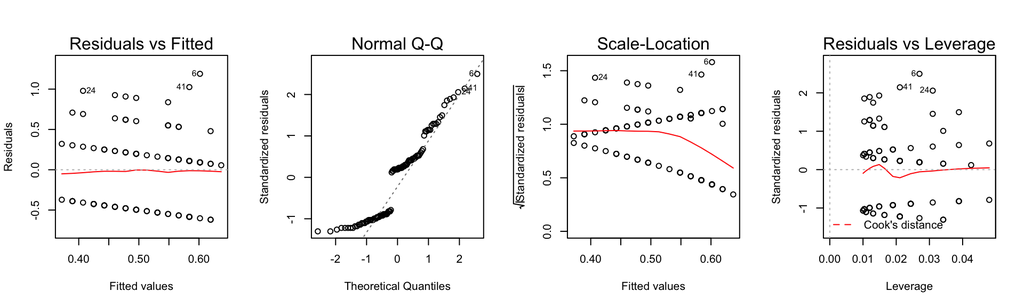

```r
par(mfrow = c(1, 4))
plot(mod_lm)
```

## The example of the GLM Poisson

### If the process generating the data is not Gaussian…

…the LM should fit more poorly the data:

```r
sum((Aliens$eggs - (exp(predict(mod_lm)) - 1))^2)
```

```
## [1] 101.4511
```

```r
sum((Aliens$eggs - exp(predict(mod_poiss)))^2)
```

```
## [1] 96.99777
```

Note: we compare the sum of squares (paying attention to do so on the same scale) as the models have been fitted on different responses, which prevents the use of any comparison based on the likelihood.

## The example of the GLM Binomial

Try for yourself!

## But, if the process is Gaussian…

```r
set.seed(1L)
x <- seq(1, 2, length = 100)
simu <- replicate(100, {
  y <- exp(rnorm(n = length(x), mean = 2 + 1 * x, sd = 0.5))
  mod_lm   <- lm(log(y) ~ x)
  mod_glm1 <- glm(log(y) ~ x, family = gaussian(link = "identity"))
  mod_glm2 <- glm(y ~ x, family = gaussian(link = "log"))
  c(mod_lm$coefficients, mod_glm1$coefficients, mod_glm2$coefficients)
})

round(rbind(
  mod_lm = c("mean int" = mean(simu[1, ]), "sd int" = sd(simu[1, ]),
             "mean slope" = mean(simu[2, ]), "sd slope" = sd(simu[2, ])),
  mod_glm1 = c(mean(simu[3, ]), sd(simu[3, ]), mean(simu[4, ]), sd(simu[4, ])),
  mod_glm2 = c(mean(simu[5, ]), sd(simu[5, ]), mean(simu[6, ]), sd(simu[6, ]))), 3)
```

```
##          mean int sd int mean slope sd slope
## mod_lm      2.001  0.208      0.997    0.137
## mod_glm1    2.001  0.208      0.997    0.137
## mod_glm2    2.113  0.290      1.005    0.191
```

The GLM2 log transforms the expected values, not the observations! So the estimates produced by this fit are biased.

## But, if the process is Gaussian…

```r
set.seed(1L)
x <- seq(1, 2, length = 100)
simu <- replicate(100, {
  y <- exp(2 + 1 * x) + rnorm(n = length(x), mean = 0, sd = 5)
  mod_lm   <- lm(log(y) ~ x)
  mod_glm1 <- glm(log(y) ~ x, family = gaussian(link = "identity"))
  mod_glm2 <- glm(y ~ x, family = gaussian(link = "log"))
  c(mod_lm$coefficients, mod_glm1$coefficients, mod_glm2$coefficients)
})

round(rbind(
  mod_lm = c("mean int" = mean(simu[1, ]), "sd int" = sd(simu[1, ]),
             "mean slope" = mean(simu[2, ]), "sd slope" = sd(simu[2, ])),
  mod_glm1 = c(mean(simu[3, ]), sd(simu[3, ]), mean(simu[4, ]), sd(simu[4, ])),
  mod_glm2 = c(mean(simu[5, ]), sd(simu[5, ]), mean(simu[6, ]), sd(simu[6, ]))), 3)
```

```
##          mean int sd int mean slope sd slope
## mod_lm      1.943  0.083      1.028    0.049
## mod_glm1    1.943  0.083      1.028    0.049
## mod_glm2    1.997  0.076      1.001    0.045
```

Here the GLM2 corresponds the simulation model so estimates produced are better than the alternatives.

## How to compare LM and GLM?

We can compare deviances but not directly:

```r
set.seed(1L)
x <- seq(1, 2, length = 100)
y <- exp(2 + 1 * x) + rnorm(n = length(x), mean = 0, sd = 5)

mod_glm  <- glm(y ~ x, family = gaussian(link = "log"))
mod_lm   <- lm(log(y) ~ x)

rbind("deviance glm"          = deviance(mod_glm), ## OK same as mod_glm$deviance
      "raw deviance lm"       = deviance(mod_lm),  ## not comparable as response = log(y)
      "corrected deviance lm" = sum((y - exp(predict(mod_lm)))^2))  ## comparable deviance for lm
```

```
##                              [,1]
## deviance glm          1995.198354
## raw deviance lm          2.323296
## corrected deviance lm 2008.581302
```

You cannot use AIC in this case as the responses differ.

To do a formal test, you can use the parametric bootstrap as we will see later!

## Interpreting parameter estimates

## Estimates with the Gaussian family

Same as LM (when link = identity)!

## Estimates with the Poisson family with log link

### Predictions for \(\eta\) and \(\mu\) differ!

```r
mod_poiss$coefficients
```

```
##  (Intercept) humans_eaten
##  -0.42147860   0.03635067
```

```r
predict(mod_poiss, newdata = data.frame(humans_eaten = 10))
```

```
##           1
## -0.05797187
```

```r
mod_poiss$coefficients[1] + 10 * mod_poiss$coefficients[2]
```

```
## (Intercept)
## -0.05797187
```

Because we used the link function `log`, this is a log number of eggs!

## Estimates with the Poisson family with log link

### Predictions for \(\eta\) and \(\mu\) differ!

```r
exp(predict(mod_poiss, newdata = data.frame(humans_eaten = 10)))
```

```
##         1
## 0.9436765
```

```r
exp(mod_poiss$coefficients[1] + 10 * mod_poiss$coefficients[2])
```

```
## (Intercept)
##   0.9436765
```

```r
predict(mod_poiss, newdata = data.frame(humans_eaten = 10), type = "response")
```

```
##         1
## 0.9436765
```

This is the average number of eggs predicted for aliens eating 10 humans.

## Estimates with the Poisson family with log link

### The regression parameters are linear for \(\eta\), not \(\mu\)!

Ex: what happens when different aliens eat one additional human?

```r
(p.eta <- predict(mod_poiss, newdata = data.frame(humans_eaten = 1:5)))
```

```
##          1          2          3          4          5
## -0.3851279 -0.3487773 -0.3124266 -0.2760759 -0.2397252
```

```r
(p.mu <- predict(mod_poiss, newdata = data.frame(humans_eaten = 1:5), type = "response"))
```

```
##         1         2         3         4         5
## 0.6803636 0.7055503 0.7316693 0.7587553 0.7868440
```

The effect is no longer constant!

## Estimates with the Poisson family with log link

Ratios are the way out:

```r
p.mu[-1] / p.mu[-5]
```

```
##        2        3        4        5
## 1.037019 1.037019 1.037019 1.037019
```

```r
exp(mod_poiss$coefficients[2])
```

```
## humans_eaten
##     1.037019
```

Eating one additional human increases the average number of eggs produced by aliens by `1.0370194` times or `3.7019437`%.

## Estimates and the Binomial with logit link

```r
(p.eta <- predict(mod_binom, newdata = data.frame(humans_eaten = 1:5)))
```

```
##          1          2          3          4          5
## -1.7351131 -1.2221713 -0.7092295 -0.1962877  0.3166541
```

```r
(p.mu <- predict(mod_binom, newdata = data.frame(humans_eaten = 1:5), type = "response"))
```

```
##         1         2         3         4         5
## 0.1499347 0.2275546 0.3297691 0.4510850 0.5785086
```

The effect is also not constant…

## Estimates and the Binomial with logit link

Odds ratios are the way out:

```r
odd <- p.mu / (1 - p.mu)
odd[-1] / odd[-5]
```

```
##        2        3        4        5
## 1.670197 1.670197 1.670197 1.670197
```

The effect is constant on the scale of the odds ratios!

And the odds ratios can also be directly deduced from the parameter estimates:

```r
exp(mod_binom$coefficients[2])
```

```
## humans_eaten
##     1.670197
```

Eating one additional human increases the **odd** of aliens having blue eyes by `1.6701974` times.

## Estimates and the Binomial with logit link

What happens when different aliens eat 10 additional humans?

```r
p.mu <- predict(mod_binom, newdata = data.frame(humans_eaten = c(0, 10, 20, 30, 40)), type = "response")
odd <- p.mu / (1 - p.mu)
odd[-1] / odd[-5]
```

```
##        2        3        4        5
## 168.9188 168.9188 168.9188 168.9188
```

It is also constant and predicted from:

```r
exp(mod_binom$coefficients[2] * 10)
```

```
## humans_eaten
##     168.9188
```

Note: as odds-ratios are ratios, a value of 0.1 means a 10 (=1/0.1) fold reduction in odds ratios.

## What you need to remember

- how to write a GLM
- that GLM can be fitted on different type of responses
- what a link function, a variance function and a linear predictor are
- how to simulate the data for a GLM
- how to convert values between the response and linear predictor scales
- that GLM estimates are fitted by maximum likelihood
- how to interpret parameter estimates from GLM Poisson and Binomial

## Table of contents

## The Generalized Linear Model: GLM

- 3.0 Introduction
- 3.1 Intervals & Tests
- 3.2 Residuals & Assumptions
- 3.3 Let's practice more